# Regresión Lineal

### Ensayo

**Autor:**

$Yeferson \ Fabian \ Rubio \ Montero$

### Contenido

1. Introducción.
2. Breve historia.
3. El planteamiento del algortimo
4. Desarrollar un ejemplo de regresión lineal, con datos reales
5. Conclusiones

**Introducción**

La humanidad vive en un constante desarrollo a nivel cognitivo, social, económico y político, es indudable que en muchos de estos aspectos la presencia de problemas son el común denominador cuando se tratan temas en masa. Sin embargo, más allás de eso, son los problemas multivariantes (implicación de varias variables) los más desgastantes cuando se cuenta con grandes bases de datos; ¿se relacionan las variables?,¿existe una dependencia?, ¿se puede tomar decesiones al respecto?, son algunas de las preguntas a priori que se suelen generar,y que hasta hace poco no se tenía una respuesta contundente, aún cuando:

*el poder determinar si existe esta relación —y, en su caso, una forma funcional para la misma— es de sumo interés. Por una parte, ello permitiría, conocidos los valores de algunas variables, efectuar predicciones sobre los valores previsibles de otra ([Tusell,2011](http://www.et.bs.ehu.es/~etptupaf/nuevo/ficheros/estad3/nreg1.pdf))*

**Breve historia**

El término "regresión" se utilizó por primera vez en el estudio de variables antropométricas: al comparar la estatura de padres e hijos, donde resultó que los hijos cuyos padres tenían una estatura muy superior al valor medio, tendían a igualarse a este, mientras que aquellos cuyos padres eran muy bajos tendían a reducir su diferencia respecto a la estatura media; es decir, "regresaban" al promedio. La constatación empírica de esta propiedad se vio reforzada más tarde con la justificación teórica de ese fenómeno.

La primera forma de regresión lineal documentada fue el método de los mínimos cuadrados que fue publicada por Legendre en 1805, Gauss publicó un trabajo en donde desarrollaba de manera más profunda el método de los mínimos cuadrados, y en dónde se incluía una versión del teorema de Gauss-Márkov.

[figure not shown]

El término lineal se emplea para distinguirlo del resto de técnicas de regresión, que emplean modelos basados en cualquier clase de función matemática. Los modelos lineales son una explicación simplificada de la realidad, mucho más ágiles y con un soporte teórico mucho más extenso por parte de la matemática y la estadística. Pero bien, como se ha dicho, se puede usar el término lineal para distinguir modelos basados en cualquier clase de aplicación.

[Información recopilada de wikipedia](https://es.wikipedia.org/wiki/Regresi%C3%B3n_lineal#:~:text=La%20primera%20forma%20de%20regresi%C3%B3n,del%20teorema%20de%20Gauss%2DM%C3%A1rkov)

### El planteamiento del algoritmo

#### Desarrollo matemático del análisis de regresión lineal

Es de interés señalar que el ajuste de un modelo de regresión no se limita a analizar la relación entre dos variables; en general, se busca relaciones del tipo:

$$Y= f(X_0,X_1,...,X_{p-1})+\epsilon$$

relacionando de manera aproximada los valores de $Y$ con los que toman otras variables, $X_0,...,X_{p-1}$.

**Notación**

Se considera una variable aleatoria $Y$ (*regresando, respuesta, o variable endógena*) generada de la siguiente forma:

$$Y= \beta_0X_0 + \beta_1X_1 +...+ \beta_{p-1}X_{p-1} + \epsilon \hspace{0.3cm} (ec.1)$$

donde:

1. $\beta_0,...,\beta_{p-1}$, parámetros fijos desconocidos.
2. $X_0,...,X_{p-1}$, varaibles explicativas no estocásticas, *regresores*, cuyos valores son fijados por el experimentador. Frecuentemente $X_0$ toma el valor constante "uno".
3. $\epsilon$ una variable aleatoria inobservable.

La ecuación ec.(1) indica que la variable aleatoria $Y$ se genera como combinación lineal de las variables explicativas, salvo en una perturbación aleatoria $\epsilon$. En un ambito de análisis de regresión el problema siempre recae en estimar los parámetros desconocidos $\beta_0,...,\beta_{p-1}$, para ello siempre se cuenta con una muestra de $N$ observaciones de la variable aleatoria $Y$, y de los correspondientes valores de las varaibles explicativas $X$ ($\epsilon$ es inobservable). La muestra permite escribir $N$ igualdades similares la ec.1:

$$ \begin{align} y_1 &= \beta_0x_{1,0} + \beta_0x_{1,1} + \dotsb + \beta_{p-1}x_{1,p-1} + \epsilon_1 \\ y_2 &= \beta_0x_{2,0} + \beta_1x_{2,1} + \dotsb + \beta_{p-1}x_{2,p-1} + \epsilon_2\\ & \vdots \\ y_N &= \beta_0x_{N,0} + \beta_1x_{N,1} + \dotsb + \beta_{p-1}x_{N,p-1} + \epsilon_N \end{align} $$

En forma matrcial, se obtine:

$$\overrightarrow{y} = X\overrightarrow{\beta} + \overrightarrow{\epsilon}$$

Donde:

*$\overrightarrow{y}$ el vector $N\times 1$ de observaciones de la variable aleatoria $Y$,

*$X$ la matriz $N\times p$ de valores de las variables explicativas. Su elemento $x_{ij}$ denota el valor de la j-ésima varaible explicativa toma en la i-ésima observación,

*$\overrightarrow{\beta}$ el vector de parámetros ($\beta_0,...,\beta_{p-1})'$,

*$\overrightarrow{\epsilon}$ el vector $N\times1$ de valores de la perturbación aleatoria $\epsilon$.

Además, se asigna a $\widehat{\beta}$ como el vector que representa los estimadores de los parámetros, y por $\widehat{\epsilon}$ al vector $N\times1$ de residuos, definidos por $\widehat{\beta}=\overrightarrow{y}-X\widehat{\beta}$, es decir, los residuos recogen la diferencia entre los valores muestrales observados y ajustados de la variable aleatoria $Y$. Para poder determinar qué impacto tienen en el modelo cada una de las variables, se emplean los coeficientes parciales estandarizados, que se obtienen al estandarizar (sustraer la media y dividir entre la desviación estándar) las variables predictoras previo ajuste del modelo. En este caso, $\beta_0$ se corresponde con el valor esperado de la variable respuesta cuando todos los predictores se encuentran en su valor promedio, y $\beta_j$ el cambio promedio esperado de la variable respuesta al incrementar en una desviación estándar la variable predictora $X_j$ , manteniéndose constantes el resto de variables.

Si bien los coeficientes de regresión suelen ser el primer objetivo de la interpretación de un modelo lineal, existen muchos otros aspectos (significancia del modelo en su conjunto, significancia de los predictores, condición de normalidad...). Estos últimos suelen ser tratados con pocO detalle cuando el único objetivo del modelo es realizar predicciones, sin embargo, son muy relevantes si se quiere realizar inferencia, es decir, explicar las relaciones entre los predictores y la variable respuesta.

**Supuestos**

Además de suponer que $\overrightarrow{Y} = X\overrightarrow{\beta} + \overrightarrow{\epsilon}$ y que la matriz $X$ es no aleatoria, se requiere lo siguiente:

1. $E[\overrightarrow{\epsilon}]=\overrightarrow{0}$
2. $E[\overrightarrow{\epsilon}\overrightarrow{\epsilon}']=\sigma^2I$
3. Rango$(X)=p<N$

Los supuestos 1), 3) se refieren en lo sucesivo a los *supuestos habituales*.El supuesto 1) no implica pérdida de generalidad ni supone ninguna restricción, al menos en el caso en que $X$ tiene entre sus columnas una cuyos valores sean constantes (y ésto suele suceder; típicamente, la primera columna está formada por “unos”). En efecto, es claro que si:

$$\overrightarrow{Y}= \beta_0\overrightarrow{1} + \beta_1\overrightarrow{x}_1 + \dotsb + \beta_{p-1}\overrightarrow{x}_{p-1} + \overrightarrow{\epsilon} \hspace{0.5cm} (ec.2)$$

y el vector de perturbaciones verifica $E[\overrightarrow{\epsilon}]=\overrightarrow{\mu}$, entonces ec.2 puede reescribirse equivalentemente como:

$$\overrightarrow{Y}= (\beta_0\overrightarrow{1} + \overrightarrow{\mu}) \beta_1\overrightarrow{x}_1 + \dotsb + \beta_{p-1}\overrightarrow{x}_{p-1} + (\overrightarrow{\epsilon}-\overrightarrow{\mu}) \hspace{0.5cm} (ec.3)$$

y (ec.3) incorpora un vector de perturbaciones $(\overrightarrow{\epsilon}-\overrightarrow{\mu})$ verificando el primero de los supuestos. El supuesto 2), bastante más restrictivo, requiere que las perturbaciones sean incorrelacionadas (covarianzas cero) y homoscedásticas (de idéntica varianza). El supuesto 3) simplemente fuerza la independencia lineal entre las $(p)$ columnas de $X$. El requerimiento $N > p$ excluye de la consideración el caso $N = p$, pues entonces $\overrightarrow{y}=X\overrightarrow{\beta}$ es un sistema de ecuaciones lineales determinado, y tiene siempre solución para algún vector $\overrightarrow{\beta}$ que hace los residuos nulos. Las estimaciones del vector $\overrightarrow{\beta}$ se obtendrían entonces resolviendo dicho sistema ([Tusell,2011](http://www.et.bs.ehu.es/~etptupaf/nuevo/ficheros/estad3/nreg1.pdf)).

El método empleado con más frecuencia es el ajuste por mínimos cuadrados ordinarios (OLS), que identifica como mejor modelo la recta (o plano si es regresión múltiple) que minimiza la suma de las desviaciones verticales entre cada dato de entrenamiento y la recta, elevadas al cuadrado.

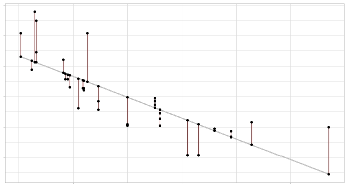

*Modelo de regresión lineal y sus errores: la línea gris representa la recta de regresión (el modelo) y los segmentos rojos el error entre esta y cada observación*.

**Aplicación del algoritmo en Python**

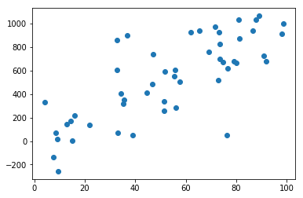

```
('Coeficiente beta1: ', array([9.73148202]))
Error cuadrático medio: 50100.55
Estadístico R_2: 0.59
```

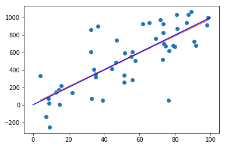

```python
import numpy as np
import random
from sklearn import linear_model
from sklearn.metrics import mean_squared_error, r2_score
import matplotlib.pyplot as plt
%matplotlib inline

# Generador de distribución de datos para regresión lineal simple
def generador_datos_simple(beta, muestras, desviacion):
  x = np.random.random(muestras) *100
  e = np.random.randn(muestras) * desviacion
  y = x * beta + e
  return x.reshape((muestras,1)), y.reshape((muestras,1))

# Parámetros de la distribución
desviacion = 200
beta = 10
n = 50
x, y = generador_datos_simple(beta, n, desviacion)

# Represento los datos generados
plt.scatter(x, y)
plt.show()
# Creo un modelo de regresión lineal
modelo = linear_model.LinearRegression()

# Entreno el modelo con los datos (X,Y)
modelo.fit(x, y)
# Ahora puedo obtener el coeficiente b_1
print('Coeficiente beta1: ', modelo.coef_[0])

# Podemos predecir usando el modelo
y_pred = modelo.predict(x)

# Por último, calculamos el error cuadrático medio y el estadístico R^2
print ('Error cuadrático medio: %.2f' % mean_squared_error(y, y_pred))
print ('Estadístico R_2: %.2f' % r2_score(y, y_pred))



# Representamos el ajuste (amarillo) y la recta Y = beta*x (verde)
plt.scatter(x, y)
plt.plot(x, y_pred, color='salmon')
x_real = np.array([0, 100])
y_real = x_real*beta
plt.plot(x_real, y_real, color='blue')
plt.show()
```

*Análsis de datos reales*

Se escogió una bases de datos de Githud sobre desempleo y otras variables económicas reportadas en los Estados Unidos desde 1941 hasta 2010. La idea es estimar los parametros de regresión lineal que existe entre desempleo vs años.

```python
import pandas as pd
Desempleo=pd.read_csv("C:/Users/lilil/Downloads/Desempleo.csv")
print(Desempleo)
```

```
    year  population  labor_force  population_percent  employed_total  \
0   1941       99900        55910                56.0           50350
1   1942       98640        56410                57.2           53750
2   1943       94640        55540                58.7           54470
3   1944       93220        54630                58.6           53960
4   1945       94090        53860                57.2           52820
5   1946      103070        57520                55.8           55250
6   1947      106018        60168                56.8           57812
7   1947      101827        59350                58.3           57038
8   1948      103068        60621                58.8           58343
9   1949      103994        61286                58.9           57651
10  1950      104995        62208                59.2           58918
11  1951      104621        62017                59.2           59961
12  1952      105231        62138                59.0           60250
13  1953      107056        63015                58.9           61179
```

[output cut: 175 more lines]

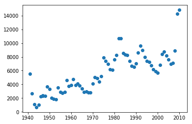

```
('Coeficiente beta1: \n', array([118.5431563]))
('Independent term: \n', -228460.64639812836)
Error cuadrático medio: 2788767.46
Estadístico R_2: 0.68
```

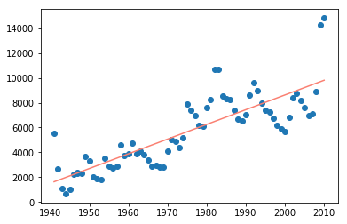

```python
import numpy as np
import random
from sklearn import linear_model
from sklearn.metrics import mean_squared_error, r2_score
import matplotlib.pyplot as plt
%matplotlib inline
#datos['Desempleo']

x=Desempleo['year'].values
y=Desempleo['unemployed'].values
# Represento los datos generados

plt.scatter(x, y)
plt.show()


# Creo un modelo de regresión lineal
modelo = linear_model.LinearRegression()

#
x=x.reshape(-1,1)

# Entreno el modelo con los datos (X,Y)
modelo.fit(x, y)
# Ahora puedo obtener el coeficiente b_1
print('Coeficiente beta1: \n', modelo.coef_)
# Este es el valor donde corta el eje Y (en X=0)
print('Independent term: \n', modelo.intercept_)

# Podemos predecir usando el modelo
y_pred = modelo.predict(x)

# Por último, calculamos el error cuadrático medio y el estadístico R^2
print ('Error cuadrático medio: %.2f' % mean_squared_error(y, y_pred))
print ('Estadístico R_2: %.2f' % r2_score(y, y_pred))
# Representamos el ajuste (amarillo)
plt.scatter(x, y)
plt.plot(x, y_pred, color='salmon')
plt.show()
```

Haciendo un cálculo adicional:

```python
#Coeficiente de correlación lineal de Pearson
import numpy as np
np.sqrt(0.68)
```

```
0.8246211251235321
```

Podemos notar que efetivamente existe una correlación lineal positiva entre el desempleo en USA y el tiempo tomado, en este caso el intervalo $[1941,2010]$.

**Conclusiones**

Como se pudo detallar el desarrollo matemático y la implementación de modelos de regresión lineal en lenguajes de programación resulta bastante práctico para llevar acabo análisis de predicción y toma de decisiones. La construcción de un modelo de regresión simple es la primera etapa del alcance y aplicación que la teoría de regresión lineal ofrece, es asombroso los resultados que se logran con modelos multiples, es decir, donde se estudia analíticamente el efecto que muchas variables regresoras le generan a una única variable respuesta. El avance descontrolado de los modelos predictivos en la estadística propiamente y su implementación en diveros lenguajes de programación, donde incluso se pueden acoplar a técnicas como el Machine Learning o deep learning son el futuro de la humanidad, los seres humanos deben acostumbrarse a tomar decisiones acorde a lo ya vivido y no hay mejor forma que usar las bases de datos ya recopiladas, porque a la final es de la experiencia donde surgen las grandes ideas y toma de decisiones.